# Universidad Politecnica Salesiana

### Nombre: Jéssica Ñauta

### Materia: Simulación

# Covid-19 infección en Ecuador. Modelos matemáticos y predicciones

Se realiza un análisis matemático simple del crecimiento de la infección en Python y dos modelos para comprender mejor la evolución de la infección.

Se crea modelos de series temporales del número total de personas infectadas hasta la fecha (es decir, las personas realmente infectadas más las personas que han sido infectadas). Estos modelos tienen parámetros , que se estimarán por ajuste de curva.

## Formulación del Problema:

Determina el objeto de la simulación. Se deben especificar los siguientes elementos:

- Resultados que se esperan del simulador: mediante el modelo logistico obtener una prediccion sobre los contagios del covid-19.
- Plan de experimentación: buscar datos de covid en el Ecuador y realizar la simulación.
- Variables de interés: variables que nos ayudaran a realizar el calculo para obtener una estadistica de infectados.
- Tipo de perturbaciones a estudiar: librerías que nos ayudaran a implementar el método de forma sencilla.
- Tratamiento estadístico de los resultados: graficar para obtener un resultado y poderlo visualizar de mejor manera las estadísticas.
- Complejidad del interfaz del simulador: no tiene una interfaz.

## Definición del sistema:

El sistema que se simulará debe estar definido perfectamente. Se debe establecer donde estará la frontera de interacción entre el sistema a estudiar y el medioambiente.

## Formulación del modelo:

En esta etapa se capturan los aspectos relevantes del sistema real. En este caso vamos a capturar los datos de cada persona para saber cuantas estuvieron infectados, cuantas ya superaron, muertes confirmads, entre otras, para poder aplicar el método y predecir el futuro sobre esta pandemia.

## Implementación del modelo en el ordenador:

Se implementa el modelo a través de un lenguaje de programación/simulación. En este caso usaremos python.

```python
# Importar las librerias para el analasis
import pandas as pd
import numpy as np
from datetime import datetime,timedelta
from sklearn.metrics import mean_squared_error
from scipy.optimize import curve_fit
from scipy.optimize import fsolve
from sklearn import linear_model
import matplotlib.pyplot as plt
%matplotlib inline
from xml.dom import minidom
from datetime import datetime
instanteInicial = datetime.now()
```

## Colección de datos:

La naturaleza y la cantidad de datos se determinan por la formulación del problema y del modelo. Pueden ser obtenidos de registros históricos, experimentos en laboratorio o mediciones realizadas en el sistema real. En este caso hemos accedido al siguiente enlace para obtener la información: https://github.com/owid/covid-19-data/tree/master/public/data

```python
# Actualizar los datos (URL)
#Datos obtenidos de: https://github.com/owid/covid-19-data/tree/master/public/data
url = 'owid-covid-data.csv'
df = pd.read_csv(url)
df= df.fillna(0)
df
```

[output not shown]

56111 rows × 49 columns

Imprimos los resultados y agregamos el numero del dia

```python
df = df[df['location'].isin(['Ecuador'])] #Filtro la Informacion solo para Ecuador
df = df.loc[:,['date','total_cases']] #Selecciono las columnas de analasis
# Expresar las fechas en numero de dias desde el 01 Enero
FMT = '%Y-%m-%d'
date = df['date']
df['date'] = date.map(lambda x : (datetime.strptime(x, FMT) - datetime.strptime("2020-01-01", FMT)).days)

df
```

|  | date | total_cases |
| --- | --- | --- |
| 14965 | -1 | 0.0 |
| 14966 | 0 | 0.0 |
| 14967 | 1 | 0.0 |
| 14968 | 2 | 0.0 |
| 14969 | 3 | 0.0 |
| 14970 | 4 | 0.0 |
| 14971 | 5 | 0.0 |
| 14972 | 6 | 0.0 |
| 14973 | 7 | 0.0 |
| 14974 | 8 | 0.0 |
| 14975 | 9 | 0.0 |
| 14976 | 10 | 0.0 |
| 14977 | 11 | 0.0 |
| 14978 | 12 | 0.0 |
| 14979 | 13 | 0.0 |
| 14980 | 14 | 0.0 |
| 14981 | 15 | 0.0 |
| 14982 | 16 | 0.0 |
| 14983 | 17 | 0.0 |
| 14984 | 18 | 0.0 |
| 14985 | 19 | 0.0 |
| 14986 | 20 | 0.0 |
| 14987 | 21 | 0.0 |
| 14988 | 22 | 0.0 |
| 14989 | 23 | 0.0 |
| 14990 | 24 | 0.0 |
| 14991 | 25 | 0.0 |
| 14992 | 26 | 0.0 |
| 14993 | 27 | 0.0 |
| 14994 | 28 | 0.0 |
| ... | ... | ... |
| 15252 | 286 | 147315.0 |
| 15253 | 287 | 148171.0 |
| 15254 | 288 | 149083.0 |
| 15255 | 289 | 150360.0 |
| 15256 | 290 | 151659.0 |
| 15257 | 291 | 152422.0 |
| 15258 | 292 | 153289.0 |
| 15259 | 293 | 153423.0 |
| 15260 | 294 | 154115.0 |
| 15261 | 295 | 155625.0 |
| 15262 | 296 | 156451.0 |
| 15263 | 297 | 158270.0 |
| 15264 | 298 | 159614.0 |
| 15265 | 299 | 161635.0 |
| 15266 | 300 | 162178.0 |
| 15267 | 301 | 163192.0 |
| 15268 | 302 | 164908.0 |
| 15269 | 303 | 166302.0 |
| 15270 | 304 | 167147.0 |
| 15271 | 305 | 168192.0 |
| 15272 | 306 | 169194.0 |
| 15273 | 307 | 169562.0 |
| 15274 | 308 | 170110.0 |
| 15275 | 309 | 171433.0 |
| 15276 | 310 | 171783.0 |
| 15277 | 311 | 172508.0 |
| 15278 | 312 | 173486.0 |
| 15279 | 313 | 174907.0 |
| 15280 | 314 | 175269.0 |
| 15281 | 315 | 175711.0 |

317 rows × 2 columns

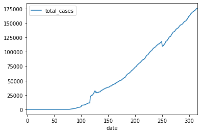

```python
df.plot(x ='date', y='total_cases')
```